# Manually specifying FFTs

Hansjörg Neth and Nathaniel Phillips

2023-06-06

## Manually specifying FFTs

We usually create fast-and-frugal trees (FFTs) from data by using the `FFTrees()` function (see the Main guide: FFTrees overview and the vignette on Creating FFTs with FFTrees() for instructions). However, we occasionally may want to design and evaluate specific FFTs (e.g., to test a hypothesis or include or exclude some variables based on theoretical considerations).

There are two ways to manually define fast-and-frugal trees with the `FFTrees()` function:

1. as a sentence using the `my.tree` argument (the easier way), or
2. as a data frame using the `tree.definitions` argument (the harder way).

Both of these methods require some data to evaluate the performance of FFTs, but will bypass the tree construction algorithms built into the **FFTrees** package. As manually created FFTs are not optimized for specific data, the key difference between fitting and predicting disappears for such FFTs. Although we can still use two sets of ‘train’ vs. ‘test’ data, a manually defined FFT is not fitted and hence should not be expected to perform systematically better on ‘train’ data than on ‘test’ data.

### 1. Using `my.tree`

The first method for manually defining an FFT is to use the `my.tree` argument, where `my.tree` is a sentence describing a (single) FFT. When this argument is specified in `FFTrees()`, the function — or rather its auxiliary `fftrees_wordstofftrees()` function — attempts to interpret the verbal description and convert it into a valid definition of an FFT (as part of an `FFTrees` object).

For example, let’s use the `heartdisease` data to find out how some predictor variables (e.g., `sex`, `age`, etc.) predict the criterion variable (`diagnosis`):

**Table 1**: Five cues and the binary criterion variable `diagnosis` for the first cases of the `heartdisease` data.

| sex | age | thal | cp | ca | diagnosis |
| --- | --- | --- | --- | --- | --- |
| 1 | 63 | fd | ta | 0 | FALSE |
| 1 | 67 | normal | a | 3 | TRUE |
| 1 | 67 | rd | a | 2 | TRUE |
| 1 | 37 | normal | np | 0 | FALSE |
| 0 | 41 | normal | aa | 0 | FALSE |
| 1 | 56 | normal | aa | 0 | FALSE |

Here’s how we could verbally describe an FFT by using the first three cues in conditional sentences:

```r
in_words <- "If sex = 1, predict True.
             If age < 45, predict False.
             If thal = {fd, normal}, predict True.
             Otherwise, predict False."
```

As we will see shortly, the `FFTrees()` function accepts such descriptions (assigned here to a character string `in_words`) as its `my.tree` argument, creates a corresponding FFT, and evaluates it on a corresponding dataset.

#### Verbally defining FFTs

Here are some **instructions** for manually specifying trees:

- Each node must start with the word “If” and should correspond to the form: `If <CUE> <DIRECTION> <THRESHOLD>, predict <EXIT>`.
- Numeric thresholds should be specified directly (without brackets), like `age > 21`.
- For categorical variables, factor thresholds must be specified within curly braces, like `sex = {male}`. For factors with sets of values, categories within a threshold should be separated by commas like `eyecolor = {blue,brown}`.
- To specify cue directions, standard logical comparisons `=`, `!=`, `<`, `>=` (etc.) are valid. For numeric cues, only use `>`, `>=`, `<`, or `<=`. For factors, only use `=` or `!=`.
- Positive exits are indicated by `True`, while negative exits are specified by `False`.
- The final node of an FFT is always bi-directional (i.e., has both a positive and a negative exit). The description of the final node always mentions its positive (`True`) exit first. The text `Otherwise, predict EXIT` that we have included in the example above is actually not necessary (and ignored).

#### Example

Now, let’s use our verbal description of an FFT (assigned to `in_words` above) as the `my.tree` argument of the `FFTrees()` function. This creates a corresponding FFT and applies it to the `heartdisease` data:

```r
# Create FFTrees from a verbal FFT description (as my.tree):
my_fft <- FFTrees(formula = diagnosis ~.,
                  data = heartdisease,
                  main = "My 1st FFT",
                  my.tree = in_words)
```

Running `FFTrees()` with the `my.tree` argument creates an object `my_fft` that contains one FFT. A verbal description of this tree can be printed by `inwords(my_fft)`, but we want to print or plot the object to evaluate the tree’s performance on training or testing data. Let’s see how well our manually constructed FFT (`my_fft`) did on the training data:

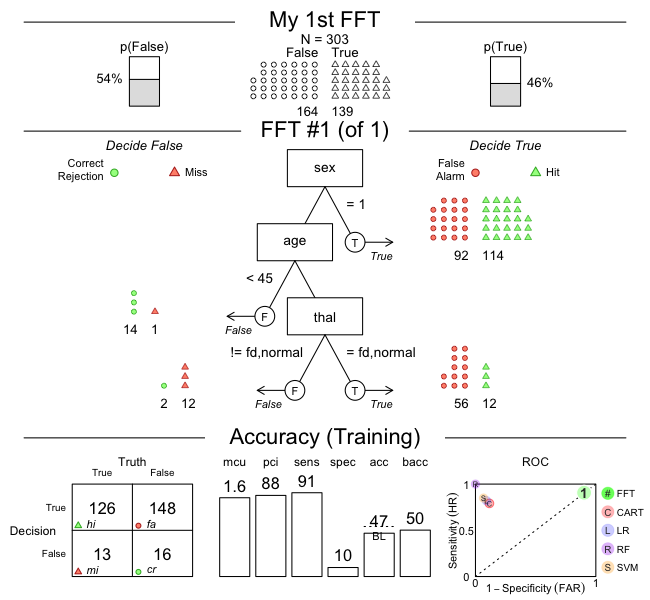

**Figure 1**: An FFT manually constructed using the `my.tree` argument of `FFTrees()`.

```r
# Inspect FFTrees object:
plot(my_fft, data = "train")
```

When manually constructing a tree, the resulting `FFTrees` object only contains a single FFT. Hence, the ROC plot (in the right bottom panel of **Figure 1**) cannot show a range of FFTs, but locates the constructed FFT in ROC space.

The formal definition of our new FFT is available from the `FFTrees` object `my_fft`:

```r
# Get FFT definition(s):
get_fft_df(my_fft)  # my_fft$trees$definitions
```

```
#> # A tibble: 1 × 7
#>    tree nodes classes cues         directions thresholds     exits
#>   <int> <int> <chr>   <chr>        <chr>      <chr>          <chr>
#> 1     1     3 n;n;c   sex;age;thal =;>=;=     1;45;fd,normal 1;0;0.5
```

Note that the 2nd node in this FFT (using the `age` cue) is predicting the *noise* outcome (i.e., a non-final exit value of `0` or `FALSE`, shown to the left). As our tree definitions always refer to the *signal* outcome (i.e., a non-final exit value of `1` or `TRUE`, shown to the right), the direction symbol of a left exit (i.e., the 2nd node in **Figure 1**: if `age < 45`, predict `0` or noise) must be flipped relative to its appearance in the tree definition (if `age >= 45`, predict `1` or signal). Thus, the plot and the formal definition describe the same FFT.

As it turns out, the performance of our first FFT created from a verbal description is a mixed affair: The tree has a rather high sensitivity (of 91%), but its low specificity (of only 10%) allows for many false alarms. Consequently, its accuracy measures fail to exceed the baseline level.

#### Creating an alternative FFT

Let’s see if we can come up with a better FFT. The following example uses the cues `thal`, `cp`, and `ca` in the `my.tree` argument:

```r
# Create a 2nd FFT from an alternative FFT description (as my.tree):
my_fft_2 <- FFTrees(formula = diagnosis ~.,
                    data = heartdisease,
                    main = "My 2nd FFT",
                    my.tree = "If thal = {rd,fd}, predict True.
                               If cp != {a}, predict False.
                               If ca > 1, predict True.
                               Otherwise, predict False.")
```

As **FFTrees** aims to interpret the `my.tree` argument to the best of its abilities, there is some flexibility in entering a verbal description of an FFT. For instance, we also could have described our desired FFT in more flowery terms:

```r
# Create a 2nd FFT from an alternative FFT description (as my.tree):
my_fft_2 <- FFTrees(formula = diagnosis ~.,
                    data = heartdisease,
                    main = "My 2nd FFT",
                    my.tree = "If thal equals {rd,fd}, we shall say True.
                               When Cp differs from {a}, let's predict False.
                               Whenever CA happens to exceed 1, we will insist on True.
                               Else, we give up and go away.")
```

However, as the vocabulary of **FFTrees** is limited, it is safer to enter cue directions in their symbolic form (i.e., using `=`, `<`, `<=`, `>`, `>=`, or `!=`).[^1] To verify that **FFTrees** interpreted our `my.tree` description as intended, let’s check whether the FFT of `inwords(my_fft_2)` yields a description that corresponds to what we wanted:

```r
inwords(my_fft_2)
```

```
#> [1] "If thal = {rd,fd}, decide True."
#> [2] "If cp != {a}, decide False."
#> [3] "If ca > 1, decide True, otherwise, decide False."
```

As this seems (a more prosaic version of) what we wanted, let’s visualize this tree (to evaluate its performance) and briefly inspect its tree definition:

```r
# Visualize FFT:
plot(my_fft_2)

# FFT definition:
get_fft_df(my_fft_2)  # my_fft_2$trees$definitions
```

```
#> # A tibble: 1 × 7
#>    tree nodes classes cues       directions thresholds exits
#>   <int> <int> <chr>   <chr>      <chr>      <chr>      <chr>
#> 1     1     3 c;c;n   thal;cp;ca =;=;>      rd,fd;a;1  1;0;0.5
```

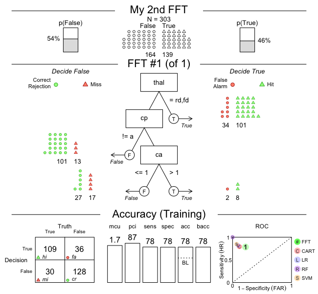

**Figure 2**: Another FFT manually constructed using the `my.tree` argument of `FFTrees()`.

```r
# Note the flipped direction value for 2nd cue (exit = '0'):
# 'if (cp  = a), predict 1' in the tree definition corresponds to
# 'if (cp != a), predict 0' in the my.tree description and plot.
```

This alternative FFT is nicely balancing sensitivity and specificity and performs much better overall. Nevertheless, it is still far from perfect — so check out whether you can create even better ones!

### 2. Using `tree.definitions`

More experienced users may want to define and evaluate more than one FFT at a time. To achieve this, the `FFTrees()` function allows providing sets of `tree.definitions` (as a data frame). However, as questions regarding specific trees usually arise later in the exploration of FFTs, the `tree.definitions` argument is mostly used in combination with an existing `FFTrees` object `x`. In this case, most parameters (e.g., regarding the `formula`, `data` and various goals) from the `FFTrees` object `x` are being kept, but the object is re-evaluated for a new set of `tree.definitions`.

As FFTs are simple and transparent rules for solving binary classification problems, it would be neat to directly manipulate and evaluate these rules. For this purpose, **FFTrees** provides a set of tree manipulation functions (see **Figure 3** below). Some of these functions extract sets of existing FFT definitions (from `x`) and convert individual FFT definitions into a more manageable (“tidy”) format. Other functions allow to edit and trim these FFT definitions (e.g., by adding, changing, reordering or removing nodes). Finally, further functions allow to re-convert individual FFT definitions into sets of definitions, and to collect and re-evaluate them on data.

The basic workflow to get, change, and use FFT definitions contains five steps:

1. Get (sets of) FFT definitions
2. Select and convert an individual FFT into a tidy data format
3. Manipulate the FFT (e.g., by changing its nodes or exits)
4. Re-convert the changed definition into the original data format
5. Collect sets of changed FFT definitions and/or evaluate them on data

Conceptually, this workflow boils down to first creating an FFT model for some data, then manipulating the model, and finally re-evaluating it on the data. The tools involved in this workflow allow editing the grammar of FFTs.

#### Overview: Retrieving, manipulating, and using FFT definitions

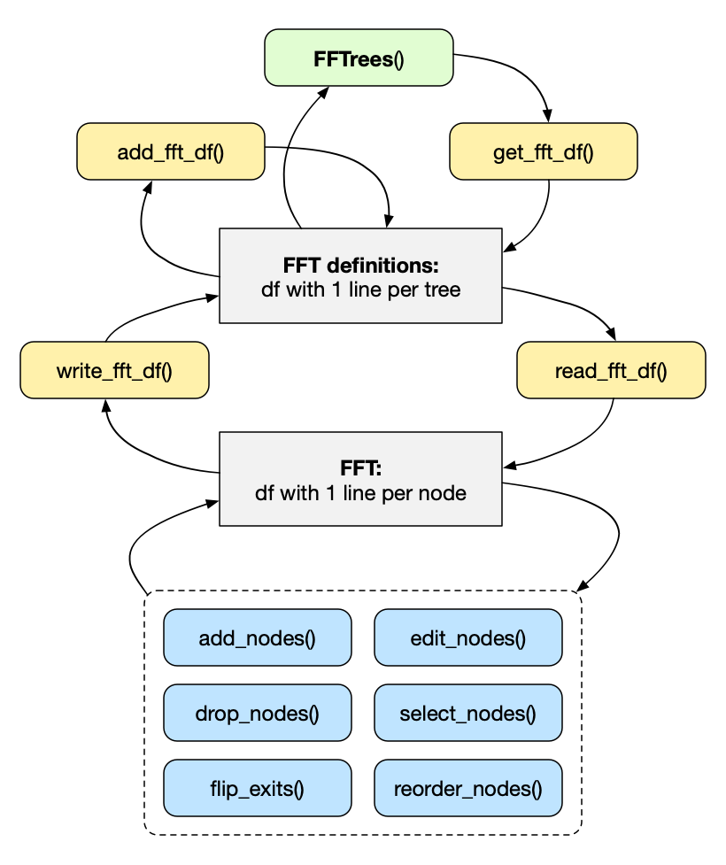

**Figure 3**: Overview of 4 tree definition and conversion functions (in yellow)  
and 6 tree trimming functions (in blue).

**Figure 3** provides an overview of the functions provided for converting and manipulating FFT definitions. We can distinguish between three cycles:

- **Cycle 1**: Obtaining and collecting sets of FFT definitions. The main `FFTrees()` function creates an `FFTrees` object `x` with and from corresponding tree definitions. The following functions get, collect, and evaluate FFT definitions:
  1. `get_fft_df()` extracts the set of current FFT definitions (from `x$trees$definitions`).
  2. `add_fft_df()` adds one or more FFT definitions to an existing set of FFT definitions. Thus, the function allows collecting sets of FFT definitions.
  3. the `tree.definitions` argument of the main `FFTrees()` function allows evaluating sets of FFT definitions for some data.
- **Cycle 2**: Converting between two tree definition formats (both stored as data frames):
  1. `read_fft_df()` selects a single FFT from a set of FFT definitions and converts it into a tidy data format (as a data frame in which each row represents a node).
  2. `write_fft_df()` converts a single FFT from the tidy data frame (with 1-row-per-node) into the 1-row-per FFT format used by `add_fft_df()` and the `tree.definitions` argument of `FFTrees()`.
- **Cycle 3**: Manipulating an individual tree definition by a set of tree editing and trimming functions:
  - `add_nodes()` allows adding new nodes to an FFT;
  - `drop_nodes()` allows deleting nodes of an FFT;
  - `edit_nodes()` allows changing existing nodes of an FFT;
  - `flip_exits()` allows changing the exit direction of existing nodes;
  - `reorder_nodes()` allows changing the order of FFT nodes;
  - `select_nodes()` allows filtering existing nodes of an FFT.

The following example illustrates the interplay of these functions in a typical workflow. When looking at **Figure 3**, we first move down on the right side (from retrieving sets of FFT definitions to manipulating individual FFTs) and then move up on the left side (to re-convert individual FFTs into sets of FFT definitions).

#### Example

We illustrate a typical workflow by redefining some FFTs that were built in the Tutorial: FFTs for heart disease and evaluating them on the (full) `heartdisease` data.

To obtain a set of existing tree definitions, we use our default algorithms to create an `FFTrees` object `x`:

```r
# Create an FFTrees object x:
x <- FFTrees(formula = diagnosis ~ .,           # criterion and (all) predictors
             data = heart.train,                # training data
             data.test = heart.test,            # testing data
             main = "Heart Disease 1",          # initial label
             decision.labels = c("low risk", "high risk"),  # exit labels
             quiet = TRUE)                      # hide user feedback
```

As we have seen in the Tutorial, evaluating this expression yields a set of 7 FFTs. Rather than evaluating them individually (e.g., by using `print(x)` or `plot(x)` commands to inspect specific trees), we now extract the tree definitions to select and modify individual FFTs. As the definitions are stored as part of the `FFTrees` object `x`, this could be achieved by evaluating `x$trees$definitions` or by `summary(x)$definitions`. Alternatively, we can use the `get_fft_df()` utility function on `x` to obtain the set of generated tree definitions:

```r
# Get tree definitions of x:
(tree_dfs <- get_fft_df(x))
```

```
#> # A tibble: 7 × 7
#>    tree nodes classes cues             directions thresholds          exits
#>   <int> <int> <chr>   <chr>            <chr>      <chr>               <chr>
#> 1     1     3 c;c;n   thal;cp;ca       =;=;>      rd,fd;a;0           1;0;0.5
#> 2     2     4 c;c;n;c thal;cp;ca;slope =;=;>;=    rd,fd;a;0;flat,down 1;0;1;0.5
#> 3     3     3 c;c;n   thal;cp;ca       =;=;>      rd,fd;a;0           0;1;0.5
#> 4     4     4 c;c;n;c thal;cp;ca;slope =;=;>;=    rd,fd;a;0;flat,down 1;1;0;0.5
#> 5     5     3 c;c;n   thal;cp;ca       =;=;>      rd,fd;a;0           0;0;0.5
#> 6     6     4 c;c;n;c thal;cp;ca;slope =;=;>;=    rd,fd;a;0;flat,down 0;0;0;0.5
#> 7     7     4 c;c;n;c thal;cp;ca;slope =;=;>;=    rd,fd;a;0;flat,down 1;1;1;0.5
```

The resulting R object `tree_dfs` is a data frame with 7 variables. Each of its 7 rows defines an FFT in the context of our current `FFTrees` object `x` (see the vignette on Creating FFTs with FFTrees() for help on interpreting tree definitions). As the “ifan” algorithm responsible for creating these trees yields a family of highly similar FFTs (which vary only by their exits, and may truncate some cues), we may want to explore alternative versions of these trees.

All 7 FFTs defined in `tree_dfs` share the three cues `thal`, `cp`, and `ca`, in this order. Let’s assume we had reasons to explore the cue order `thal`, `ca`, and `cp`.

#### Obtaining individual tree definitions

Before we can apply our tree editing functions, we first select an initial FFT that we want to manipulate further. This is the job of `read_fft_df()` (see **Cycle 2** of **Figure 3**):

- `read_fft_df()` selects an FFT definition and converts it into a tidy data frame.

In our present case, we select and convert tree `1`:

```r
(fft_1 <- read_fft_df(ffts_df = tree_dfs, tree = 1))
```

```
#>   class  cue direction threshold exit
#> 1     c thal         =     rd,fd    1
#> 2     c   cp         =         a    0
#> 3     n   ca         >         0  0.5
```

The resulting R object `fft_1` selected the definition of tree 1 and converted it into a tidy data frame. Each of its 3 rows defines a node of this FFT. This format can be understood and manipulated more easily than the more compact format used in row 1 of `tree_dfs` (but both formats can be converted into each other by the complementary functions `read_fft_df()` and `write_fft_df()`).

#### Manipulating individual tree definitions

Having selected one FFT and converted it into a tidy data frame `fft_1`, we can use various tree trimming functions to edit or manipulate the definition of an individual tree (see **Cycle 3** of **Figure 3**).

**Reordering nodes**  
In our example, our selected FFT uses the cues `thal`, `cp`, and `ca`, but we wanted to explore the alternative cue order `thal`, `ca`, and `cp`. In other words, we need to swap the order of the 2nd and 3rd cues of `fft_1`. This is the purpose of the `reorder_nodes()` function:

- `reorder_nodes()` allows changing the order of FFT nodes.

In contrast to the `read_fft_df()` function above, the tree editing functions of **Cycle 3** all require an individual FFT-definition (as a tidy data frame) as their first argument `fft`. In the case of `reorder_nodes()`, the second argument `order` specifies a numeric vector for the desired node positions (i.e., the integers from 1 to `nrow(fft)` in any order). Thus, swapping the order of the 2nd and 3rd nodes of `fft_1` is achieved as follows:

```r
(my_fft_1 <- reorder_nodes(fft = fft_1, order = c(1, 3, 2)))
```

```
#> reorder_nodes: Former exit node now is node 2
```

```
#>   class  cue direction threshold exit
#> 1     c thal         =     rd,fd    1
#> 2     n   ca         >         0    1
#> 3     c   cp         =         a  0.5
```

Swapping the final two nodes implies that the final node of `fft_1` (using the numerical cue `ca`) becomes a non-final cue, whereas the previous middle node (using a categorical cue `cp`) becomes a final cue (see the corresponding feedback message). By default, the previous exit cue becomes a signal exit (here: exit 1, i.e., predicting a TRUE value for the `diagnosis` criterion). Saving the resulting tree definition (stored in the same tidy data frame format as `fft_1`) as an R object `my_fft_1` will allow us to collect our modified FFTs later.

**Flipping exits** As we had no specific exit structure in mind when deciding to explore the cue order `thal`, `ca`, and `cp`, we will explore all possible exit directions. As every non-final node allows for two alternative exits, a tree containing $n$ nodes has $2^{(n-1)}$ exit structures (i.e., $2^2 = 4$ for 3 cues). The $3$ exit structures in addition to `my_fft_1` can be obtained by flipping the exit directions of the first, second, or both non-final nodes. Each alternative can be achieved by applying the `flip_exits()` function to `my_fft_1`:

- `flip_exits()` allows changing the exit direction of existing nodes.

For instance, the tree definition with a signal exit at the first node of `my_fft_1` can be reversed into a non-signal node as follows:

```r
(my_fft_2 <- flip_exits(my_fft_1, nodes = 1))
```

```
#>   class  cue direction threshold exit
#> 1     c thal         =     rd,fd    0
#> 2     n   ca         >         0    1
#> 3     c   cp         =         a  0.5
```

#### Using **magrittr** pipes to combine steps

The tree conversion and editing functions do not need to be used separately. As their first argument represents the data object to be manipulated, they can be viewed as verbs in a tree manipulation language and chained into longer command sequences by using the **magrittr** pipe operator. For instance, reversing the exit of the 2nd cue of `my_fft_1` could be achieved as follows:

```r
library(magrittr)

(my_fft_3 <- my_fft_1 %>%
  flip_exits(nodes = 2))
```

```
#>   class  cue direction threshold exit
#> 1     c thal         =     rd,fd    1
#> 2     n   ca         >         0    0
#> 3     c   cp         =         a  0.5
```

```r
(my_fft_4 <- x %>%
  get_fft_df() %>%
  read_fft_df(tree = 1) %>%
  reorder_nodes(order = c(1, 3, 2)) %>%
  flip_exits(nodes = c(1, 2)))
```

```
#> reorder_nodes: Former exit node now is node 2
```

```
#>   class  cue direction threshold exit
#> 1     c thal         =     rd,fd    0
#> 2     n   ca         >         0    0
#> 3     c   cp         =         a  0.5
```

To evaluate our four alternative tree definitions, we need to re-convert them into the 1-line-per-FFT format (using `write_fft_df()`) and gather them in a single data frame (using `add_fft_df()`). In **Figure 3**, this corresponds to moving upwards on the left (from individual FFT definitions in a tidy data frame to combining sets of FFT definitions in a single data frame).

#### Re-converting and collecting sets of tree definitions

Having created four modified tree definitions (i.e., `my_fft_1` to `my_fft_4`), we now want to re-convert them from the tidy data frame (with each row representing an FFT node) to the (non-tidy) data frame format (in which each row represents and entire FFT). The more compact format allows us to gather several FFT definitions in one data frame, so that we can evaluate them together for some data in a call to the main `FFTrees()` function. In **Figure 3**, the corresponding steps are shown on the left sides of **Cycle 2** and **Cycle 1**.

To re-convert between the two tree definition formats (both stored as data frames), we use the `write_fft_df()` function:

- `write_fft_df()` converts a single FFT from the tidy data frame (with 1-row-per-node) into the 1-row-per FFT format used by `add_fft_df()` and the `tree.definitions` argument of `FFTrees()`.

In addition to the FFT definition to convert (e.g., `my_fft_1`), the `tree` argument allows providing a numeric ID which will later allow us to identify the FFT within a set:

```r
(my_tree_dfs <- write_fft_df(my_fft_1, tree = 1))
```

```
#>   tree nodes classes       cues directions thresholds   exits
#> 1    1     3   c;n;c thal;ca;cp      =;>;=  rd,fd;0;a 1;1;0.5
```

This creates an R object `my_tree_dfs` as a (non-tidy) data frame in which the definition of `my_fft_1` occupies only one row.

Next, we add the other FFT definitions to the `my_tree_dfs` data frame. This can be achieved by the `add_fft_df()` function:

- `add_fft_df()` adds one or more FFT definitions to an existing set of FFT definitions. Thus, the function allows collecting sets of FFT definitions.

However, as this first requires converting each of the tidy FFT definitions into the more compact 1-row-per FFT format, we use a series of command pipes. Each pipe starts from a tidy FFT definition and applies `write_fft_df()` (with an ID) and `add_fft_df` (to `my_tree_dfs`), before re-assigning the modified data frame as `my_tree_dfs` again:

```r
my_tree_dfs <- my_fft_2 %>%
  write_fft_df(tree = 2) %>%
  add_fft_df(my_tree_dfs)

my_tree_dfs <- my_fft_3 %>%
  write_fft_df(tree = 3) %>%
  add_fft_df(my_tree_dfs)

my_tree_dfs <- my_fft_4 %>%
  write_fft_df(tree = 4) %>%
  add_fft_df(my_tree_dfs)

my_tree_dfs
```

```
#>   tree nodes classes       cues directions thresholds   exits
#> 1    1     3   c;n;c thal;ca;cp      =;>;=  rd,fd;0;a 1;1;0.5
#> 2    2     3   c;n;c thal;ca;cp      =;>;=  rd,fd;0;a 0;1;0.5
#> 3    3     3   c;n;c thal;ca;cp      =;>;=  rd,fd;0;a 1;0;0.5
#> 4    4     3   c;n;c thal;ca;cp      =;>;=  rd,fd;0;a 0;0;0.5
```

The resulting data frame `my_tree_dfs` contains 4 FFT definitions in its 4 rows. Per our design (above), they only differ in the values of their `tree` ID and the structures of their `exits`.

#### Applying sets of tree definitions to data

Having edited and collected a set of tree definitions, we now can evaluate the corresponding FFTs on some data. We can do this by providing our set of tree definitions (stored in the `my_tree_dfs` data frame) to the `tree.definitions` argument of the main `FFTrees()` function:

- The `tree.definitions` argument of the main `FFTrees()` function allows evaluating sets of FFT definitions for some data.

When using the main `FFTrees()` function with a set of `tree.definitions` (as a data frame in which each line contains the definition of one FFT), we can provide an existing `FFTrees` object (e.g., `x` from above). Importantly, however, the input of `tree.definitions` prevents the generation of new FFTs (via the “ifan” or “dfan” algorithms) and instead evaluates the FFT definitions provided on the data specified:[^2]

```r
# Evaluate tree.definitions for an existing FFTrees object y:
y <- FFTrees(object = x,                      # an existing FFTrees object
             tree.definitions = my_tree_dfs,  # new set of FFT definitions
             main = "Heart Disease 2"         # new label
             )
```

We now can assess and visualize the performance of the FFTs in the usual ways, e.g., by the `summary()`, `print()` and `plot()` functions for `y` or its trees:

```r
summary(y)
```

```
#> Heart Disease 2
#>
#> FFTrees
#> - Trees: 4 fast-and-frugal trees predicting diagnosis
#> - Parameters: algorithm = 'ifan', max.levels = 4,
#>               stopping.rule = 'exemplars', stopping.par = 0.1,
#>               goal = 'bacc', goal.chase = 'bacc', goal.threshold = 'bacc'.
#>
#>
#> Table: Tree definitions.
#>
#> | tree| nodes|classes |cues       |directions |thresholds |exits   |
#> |----:|-----:|:-------|:----------|:----------|:----------|:-------|
#> |    1|     3|c;n;c   |thal;ca;cp |=;>;=      |rd,fd;0;a  |1;0;0.5 |
#> |    2|     3|c;n;c   |thal;ca;cp |=;>;=      |rd,fd;0;a  |0;1;0.5 |
#> |    3|     3|c;n;c   |thal;ca;cp |=;>;=      |rd,fd;0;a  |1;1;0.5 |
#> |    4|     3|c;n;c   |thal;ca;cp |=;>;=      |rd,fd;0;a  |0;0;0.5 |
#>
#>
#> Table: Tree statistics on training data [p(True) = 44%].
#>
#> | tree|   n| hi| fa| mi| cr| sens| spec|  far|  ppv|  npv| dprime|  acc| bacc| wacc| cost_dec| cost_cue| cost|  pci|  mcu|
#> |----:|---:|--:|--:|--:|--:|----:|----:|----:|----:|----:|------:|----:|----:|----:|--------:|--------:|----:|----:|----:|
#> |    1| 150| 54| 18| 12| 66| 0.82| 0.79| 0.21| 0.75| 0.85|   1.69| 0.80| 0.80| 0.80|     0.20|        0| 0.20| 0.86| 1.76|
#> |    2| 150| 44|  7| 22| 77| 0.67| 0.92| 0.08| 0.86| 0.78|   1.79| 0.81| 0.79| 0.79|     0.19|        0| 0.19| 0.88| 1.58|
#> |    3| 150| 63| 42|  3| 42| 0.95| 0.50| 0.50| 0.60| 0.93|   1.66| 0.70| 0.73| 0.73|     0.30|        0| 0.30| 0.85| 1.98|
#> |    4| 150| 28|  2| 38| 82| 0.42| 0.98| 0.02| 0.93| 0.68|   1.74| 0.73| 0.70| 0.70|     0.27|        0| 0.27| 0.87| 1.68|
#>
#>
#> Table: Tree statistics on test data [p(True) = 48%].
#>
#> | tree|   n| hi| fa| mi| cr| sens| spec|  far|  ppv|  npv| dprime|  acc| bacc| wacc| cost_dec| cost_cue| cost|  pci|  mcu|
#> |----:|---:|--:|--:|--:|--:|----:|----:|----:|----:|----:|------:|----:|----:|----:|--------:|--------:|----:|----:|----:|
#> |    1| 153| 64| 19|  9| 61| 0.88| 0.76| 0.24| 0.77| 0.87|   1.86| 0.82| 0.82| 0.82|     0.18|        0| 0.18| 0.87| 1.69|
#> |    2| 153| 49|  8| 24| 72| 0.67| 0.90| 0.10| 0.86| 0.75|   1.71| 0.79| 0.79| 0.79|     0.21|        0| 0.21| 0.87| 1.70|
#> |    3| 153| 70| 45|  3| 35| 0.96| 0.44| 0.56| 0.61| 0.92|   1.55| 0.69| 0.70| 0.70|     0.31|        0| 0.31| 0.85| 1.90|
#> |    4| 153| 28|  0| 45| 80| 0.38| 1.00| 0.00| 1.00| 0.64|   2.44| 0.71| 0.69| 0.69|     0.29|        0| 0.29| 0.87| 1.71|
```

```r
# Visualize individual FFTs:
# plot(y, tree = 1)
```

Comparing the accuracy statistics of our new FFTs (in object `y`) to our original FFTs (in object `x`) shows that swapping the 2nd and 3rd cue had hardly an effect. Upon reflection, this is not surprising: Most people are still classified into the same categories as before. However, if we were to evaluate the costs of classification (e.g., by considering the `pci` and `mcu` measures or the `cost` measures for cue usage), we could still detect differences between FFTs that show the same accuracy.

#### Details

We just created a new `FFTrees` object `y` by using `FFTrees` object `x` for a set of customized FFTs defined by the `tree.definitions` argument. This circumvented the FFT building algorithms and used the provided FFT definitions instead. Thus, the ordinary distinction between training and test data no longer applies in this context: As no model is being fitted here, both sets were used to evaluate the FFTs in `tree.definitions` on these data. Acknowledging this, we may use the full dataset of `heartdisease`, rather than splitting it into two distinct subsets:

```r
# Create a new FFTrees object z:
z <- FFTrees(formula = diagnosis ~ .,
             data = heartdisease,             # using full dataset
             tree.definitions = my_tree_dfs,  # new set of FFT definitions
             main = "Heart Disease 3"         # new label
             )
```

As before, we can evaluate the performance of our FFTs by obtaining a summary, or printing or plotting individual FFTs from the `FFTrees` object `z`:

```r
# Summarize results:
summary(z)

# Visualize an FFT:
plot(z, tree = 1)
```

Finally, if we mostly care about comparing our new FFTs with the automatically created ones, we could have added our new set `my_tree_dfs` to the old set (`tree_dfs`, obtained from `x` above).

```r
(all_fft_dfs <- add_fft_df(my_tree_dfs, tree_dfs))
```

```
#> # A tibble: 11 × 7
#>     tree nodes classes cues             directions thresholds          exits
#>    <int> <int> <chr>   <chr>            <chr>      <chr>               <chr>
#>  1     1     3 c;c;n   thal;cp;ca       =;=;>      rd,fd;a;0           1;0;0.5
#>  2     2     4 c;c;n;c thal;cp;ca;slope =;=;>;=    rd,fd;a;0;flat,down 1;0;1;0.5
#>  3     3     3 c;c;n   thal;cp;ca       =;=;>      rd,fd;a;0           0;1;0.5
#>  4     4     4 c;c;n;c thal;cp;ca;slope =;=;>;=    rd,fd;a;0;flat,down 1;1;0;0.5
#>  5     5     3 c;c;n   thal;cp;ca       =;=;>      rd,fd;a;0           0;0;0.5
#>  6     6     4 c;c;n;c thal;cp;ca;slope =;=;>;=    rd,fd;a;0;flat,down 0;0;0;0.5
#>  7     7     4 c;c;n;c thal;cp;ca;slope =;=;>;=    rd,fd;a;0;flat,down 1;1;1;0.5
#>  8     8     3 c;n;c   thal;ca;cp       =;>;=      rd,fd;0;a           1;1;0.5
#>  9     9     3 c;n;c   thal;ca;cp       =;>;=      rd,fd;0;a           0;1;0.5
#> 10    10     3 c;n;c   thal;ca;cp       =;>;=      rd,fd;0;a           1;0;0.5
#> 11    11     3 c;n;c   thal;ca;cp       =;>;=      rd,fd;0;a           0;0;0.5
```

Doing so (e.g., by using the `add_fft_df()` function) creates a superset of 11 tree definitions, which can be evaluated together on the `heartdisease` data:

```r
# Create a new FFTrees object a:
all <- FFTrees(formula = diagnosis ~ .,
               data = heartdisease,             # using full dataset
               tree.definitions = all_fft_dfs,  # new set of FFT definitions
               main = "Heart Disease 4",        # new label
)

# Summarize results:
summary(all)
```

Evaluating the performance of the corresponding FFTs (e.g., by `summary(all)`) shows that reversing the final two cues had little to no effects on accuracy (but note minor differences in costs, e.g., `mcu`).[^3]

## Vignettes

Here is a complete list of the vignettes available in the **FFTrees** package:

|  | Vignette | Description |
| --- | --- | --- |
|  | Main guide: FFTrees overview | An overview of the **FFTrees** package |
| 1 | Tutorial: FFTs for heart disease | An example of using `FFTrees()` to model heart disease diagnosis |
| 2 | Accuracy statistics | Definitions of accuracy statistics used throughout the package |
| 3 | Creating FFTs with FFTrees() | Details on the main `FFTrees()` function |
| 4 | Manually specifying FFTs | How to directly create FFTs without using the built-in algorithms |
| 5 | Visualizing FFTs | Plotting `FFTrees` objects, from full trees to icon arrays |
| 6 | Examples of FFTs | Examples of FFTs from different datasets contained in the package |

[^1]: Interpretable `my.tree` descriptions must avoid using “is” and “is not” without additional qualifications (like “equal”, “different”, “larger”, “smaller”, etc.).
[^2]: If the `tree.definitions` contain cue variables or values that cannot be found in the data, this will result in errors.
[^3]: Note that applying FFT definitions to data resulted in re-sorting the tree IDs according to the current `goal`.